# MissingValuesPreprovessing

2022-09-18

Ponemos la carpeta en la que estamos y cargamos el dataset elegido

```r
setwd("/home/pablesky/Documentos/MD-FIB/Refactor")
dd<- read.csv("weathertrain.csv")
```

Vamos a mirar de cada columna como está estructurado Cargamos la estructura de la tabla.

```r
dimensiones <- dim(dd)
filas <- dimensiones[1]
columnas <- dimensiones[2]
```

Hacemos el bucle para ir comprovando.

```r
indexColumnas <- (2:columnas)
for (i in indexColumnas) {
  columnTitle <- names(dd)[i]
  columnaValores <- dd[,i]
  print(columnTitle)
  print(class(columnaValores))
  print(table(columnaValores, useNA = "ifany"))
}
```

```
## [1] "Location"
## [1] "character"
## columnaValores
##         Adelaide           Albany           Albury     AliceSprings
##             2178             2051             2142             2119
##    BadgerysCreek         Ballarat          Bendigo         Brisbane
##             2041             2122             2110             2202
##           Cairns         Canberra            Cobar     CoffsHarbour
##             2101             2393             2090             2066
##         Dartmoor           Darwin        GoldCoast           Hobart
##             2067             2217             2057             2239
##        Katherine       Launceston        Melbourne MelbourneAirport
##             1065             2072             1695             2139
##          Mildura            Moree     MountGambier      MountGinini
##             2124             2020             2140             2025
##        Newcastle             Nhil        NorahHead    NorfolkIsland
##             2096             1136             2028             2038
##        Nuriootpa       PearceRAAF          Penrith            Perth
##             2110             1953             2059             2262
##     PerthAirport         Portland         Richmond             Sale
##             2167             2113             2060             2093
##       SalmonGums           Sydney    SydneyAirport       Townsville
##             2031             2361             2100             2106
##      Tuggeranong            Uluru       WaggaWagga          Walpole
##             2099             1040             2068             1989
##         Watsonia      Williamtown      Witchcliffe       Wollongong
##             2113             1816             2060             2090
##          Woomera
##             2053
## [1] "MinTemp"
## [1] "numeric"
## columnaValores
## -8.5 -8.2   -8 -7.8 -7.6 -7.5 -7.3 -7.2 -7.1   -7 -6.9 -6.8 -6.7 -6.6 -6.5 -6.4
##    1    1    2    1    1    1    1    1    1    5    2    1    5    3    6    3
## -6.3 -6.2 -6.1   -6 -5.9 -5.8 -5.7 -5.6 -5.5 -5.4 -5.3 -5.2 -5.1   -5 -4.9 -4.8
##    4    2    3    5    6    9    3    4    6    5   11    4    9   13    8   14
## -4.7 -4.6 -4.5 -4.4 -4.3 -4.2 -4.1   -4 -3.9 -3.8 -3.7 -3.6 -3.5 -3.4 -3.3 -3.2
##   15   17   17   14   17   20   13   21   16   25   23   18   27   35   22   26
## -3.1   -3 -2.9 -2.8 -2.7 -2.6 -2.5 -2.4 -2.3 -2.2 -2.1   -2 -1.9 -1.8 -1.7 -1.6
##   26   30   31   38   38   32   41   43   40   50   53   51   39   56   64   63
```

[output cut: 743 more lines]

```
##   15   14   16   21   15   12   16   16   10   11   14   11   13    7    9   10
## 42.4 42.5 42.6 42.7 42.8 42.9   43 43.1 43.2 43.3 43.4 43.5 43.6 43.7 43.8 43.9
##   12    5    5    5    5    6    4    4    4    4    3    4    3    2    1    3
##   44 44.1 44.7 44.8 45.2 45.3 45.8 45.9 46.1 46.2 46.7 <NA>
##    3    2    1    3    2    2    2    1    3    1    1 1904
## [1] "RainToday"
## [1] "character"
## columnaValores
##    No   Yes  <NA>
## 76481 22056   979
## [1] "RainTomorrow"
## [1] "integer"
## columnaValores
##     0     1
## 77157 22359
```

Vamos a ver cuales son las columnas que son carácteres

```r
indexColumnas <- (2:columnas)
for (i in indexColumnas) {
  if (class(dd[,i]) == "character") {
    print(i)
    print(names(dd)[i])
    print(table(dd[,i], useNA="ifany"))
  }
}
```

```
## [1] 2
## [1] "Location"
##
##         Adelaide           Albany           Albury     AliceSprings
##             2178             2051             2142             2119
##    BadgerysCreek         Ballarat          Bendigo         Brisbane
##             2041             2122             2110             2202
##           Cairns         Canberra            Cobar     CoffsHarbour
##             2101             2393             2090             2066
##         Dartmoor           Darwin        GoldCoast           Hobart
##             2067             2217             2057             2239
##        Katherine       Launceston        Melbourne MelbourneAirport
##             1065             2072             1695             2139
##          Mildura            Moree     MountGambier      MountGinini
##             2124             2020             2140             2025
##        Newcastle             Nhil        NorahHead    NorfolkIsland
##             2096             1136             2028             2038
##        Nuriootpa       PearceRAAF          Penrith            Perth
##             2110             1953             2059             2262
##     PerthAirport         Portland         Richmond             Sale
##             2167             2113             2060             2093
##       SalmonGums           Sydney    SydneyAirport       Townsville
##             2031             2361             2100             2106
##      Tuggeranong            Uluru       WaggaWagga          Walpole
##             2099             1040             2068             1989
##         Watsonia      Williamtown      Witchcliffe       Wollongong
##             2113             1816             2060             2090
##          Woomera
##             2053
## [1] 8
## [1] "WindGustDir"
##
##    E  ENE  ESE    N   NE  NNE  NNW   NW    S   SE  SSE  SSW   SW    W  WNW  WSW
## 6341 5558 5101 6323 4956 4569 4589 5599 6228 6475 6329 6023 6233 6843 5664 6164
## <NA>
## 6521
## [1] 10
## [1] "WindDir9am"
##
##    E  ENE  ESE    N   NE  NNE  NNW   NW    S   SE  SSE  SSW   SW    W  WNW  WSW
## 6333 5357 5312 8052 5323 5600 5457 5975 5995 6311 6214 5147 5808 5790 5041 4795
## <NA>
## 7006
## [1] 11
## [1] "WindDir3pm"
##
##    E  ENE  ESE    N   NE  NNE  NNW   NW    S   SE  SSE  SSW   SW    W  WNW  WSW
## 5839 5413 5850 6065 5710 4561 5437 5917 6653 7410 6386 5576 6451 6897 6063 6640
## <NA>
## 2648
## [1] 22
## [1] "RainToday"
##
##    No   Yes  <NA>
## 76481 22056   979
```

PD:One hot encoding no es posible, hay problemas con el tamaño del vector.

E ENE ESE N NE NNE NNW NW S SE SSE SSW SW W WNW WSW ;  
1 2 3 4 5 6 7 8 9 10 11 12 13 14 15 16 NA

```r
dd[,23][dd[,23] == 1] = "Yes"
dd[,23][dd[,23] == 0] = "No"
print(class(dd[,23]))
```

```
## [1] "character"
```

```r
print(table(dd[,23], useNA="ifany"))
```

```
##
##    No   Yes
## 77157 22359
```

Acortamos nombre de las ciudades

```r
dd[,2][dd[,2] == "Adelaide"] = "ADEL"
dd[,2][dd[,2] == "Albany"] = "ALB"
dd[,2][dd[,2] == "Albury"] = "ABX"
dd[,2][dd[,2] == "AliceSprings"] = "ASP"
dd[,2][dd[,2] == "BadgerysCreek"] = "BC"
dd[,2][dd[,2] == "Ballarat"] = "BLL"
dd[,2][dd[,2] == "Bendigo"] = "BXG"
dd[,2][dd[,2] == "Brisbane"] = "BNE"
dd[,2][dd[,2] == "Cairns"] = "CNS"
dd[,2][dd[,2] == "Canberra"] = "CBR"
dd[,2][dd[,2] == "Cobar"] = "COB"
dd[,2][dd[,2] == "CoffsHarbour"] = "CHR"
dd[,2][dd[,2] == "Dartmoor"] = "DTR"
dd[,2][dd[,2] == "Darwin"] = "DRW"
dd[,2][dd[,2] == "GoldCoast"] = "GCT"
dd[,2][dd[,2] == "Hobart"] = "HBT"
dd[,2][dd[,2] == "Katherine"] = "KTE"
dd[,2][dd[,2] == "Launceston"] = "LCT"
dd[,2][dd[,2] == "Melbourne"] = "MBE"
dd[,2][dd[,2] == "MelbourneAirport"] = "MBEA"
dd[,2][dd[,2] == "Mildura"] = "MLD"
dd[,2][dd[,2] == "Moree"] = "MEE"
dd[,2][dd[,2] == "MountGambier"] = "MGR"
dd[,2][dd[,2] == "MountGinini"] = "MGI"
dd[,2][dd[,2] == "Newcastle"] = "NWC"
dd[,2][dd[,2] == "Nhil"] = "NHIL"
dd[,2][dd[,2] == "NorahHead"] = "NHD"
dd[,2][dd[,2] == "NorfolkIsland"] = "NFI"
dd[,2][dd[,2] == "Nuriootpa"] = "NTA"
dd[,2][dd[,2] == "PearceRAAF"] = "PRF"
dd[,2][dd[,2] == "Penrith"] = "PRT"
dd[,2][dd[,2] == "Perth"] = "PRH"
dd[,2][dd[,2] == "PerthAirport"] = "PRHA"
dd[,2][dd[,2] == "Portland"] = "PRL"
dd[,2][dd[,2] == "Richmond"] = "RHD"
dd[,2][dd[,2] == "Sale"] = "SALE"
dd[,2][dd[,2] == "SalmonGums"] = "SGS"
dd[,2][dd[,2] == "Sydney"] = "SYD"
dd[,2][dd[,2] == "SydneyAirport"] = "SYDA"
dd[,2][dd[,2] == "Townsville"] = "TVE"
dd[,2][dd[,2] == "Tuggeranong"] = "TGG"
dd[,2][dd[,2] == "Uluru"] = "URU"
dd[,2][dd[,2] == "WaggaWagga"] = "WAG"
dd[,2][dd[,2] == "Walpole"] = "WPE"
dd[,2][dd[,2] == "Watsonia"] = "WTS"
dd[,2][dd[,2] == "Williamtown"] = "WLT"
dd[,2][dd[,2] == "Witchcliffe"] = "WTF"
dd[,2][dd[,2] == "Wollongong"] = "WLG"
dd[,2][dd[,2] == "Woomera"] = "WMA"
print(class(dd[,2]))
```

```
## [1] "character"
```

```r
print(table(dd[,2], useNA="ifany"))
```

```
##
##  ABX ADEL  ALB  ASP   BC  BLL  BNE  BXG  CBR  CHR  CNS  COB  DRW  DTR  GCT  HBT
## 2142 2178 2051 2119 2041 2122 2202 2110 2393 2066 2101 2090 2217 2067 2057 2239
##  KTE  LCT  MBE MBEA  MEE  MGI  MGR  MLD  NFI  NHD NHIL  NTA  NWC  PRF  PRH PRHA
## 1065 2072 1695 2139 2020 2025 2140 2124 2038 2028 1136 2110 2096 1953 2262 2167
##  PRL  PRT  RHD SALE  SGS  SYD SYDA  TGG  TVE  URU  WAG  WLG  WLT  WMA  WPE  WTF
## 2113 2059 2060 2093 2031 2361 2100 2099 2106 1040 2068 2090 1816 2053 1989 2060
##  WTS
## 2113
```

Comprobamos que los valores NA no son aleatorios

```r
titulos <- table(dd[,2])
columna7 <- c()
for (i in names(titulos)) {
  temp <- dd[dd$Location == i,]

  if (dim(table(temp[,17],useNA="ifany")) == 1) {
    columna7 <- append(columna7, i)
  }
}

print(columna7)
```

```
## [1] "MGI" "NWC" "PRT" "SGS"
```

```r
columna6 <- c()
for (i in names(titulos)) {
  temp <- dd[dd$Location == i,]

  if (dim(table(temp[,16],useNA="ifany")) == 1) {
    columna6 <- append(columna6, i)
  }
}

print(columna6)
```

```
## [1] "MGI" "NWC" "PRT" "SGS"
```

```r
dd[,6]<-NULL
dd[,6]<-NULL
dd[,16]<-NULL
dd[,16]<-NULL
```

Checkpoint

```r
dimensiones <- dim(dd)
filas <- dimensiones[1]
columnas <- dimensiones[2]

indexColumnas <- (2:columnas)
for (i in indexColumnas) {
  columnTitle <- names(dd)[i]
  columnaValores <- dd[,i]
  print(columnTitle)
  print(sum(is.na(columnaValores)))
}
```

```
## [1] "Location"
## [1] 0
## [1] "MinTemp"
## [1] 443
## [1] "MaxTemp"
## [1] 230
## [1] "Rainfall"
## [1] 979
## [1] "WindGustDir"
## [1] 6521
## [1] "WindGustSpeed"
## [1] 6480
## [1] "WindDir9am"
## [1] 7006
## [1] "WindDir3pm"
```

[output cut: 21 more lines]

numVariables son las columnas que tienen categoria numerica, se podía hacer automatico pero me da un poquito de perecita :)

aux es la tabla con solo las columnas numVariables

noNA es la tabla con las filas que no tienen ningun valor NA, si no dropeamos

Perdemos solamente 15707 de 99516 filas.

```r
library(class)

numVariables<-c(3, 4, 5, 7, 10, 11, 12, 13, 14, 15, 16, 17)
aux<-dd[,numVariables]
noNA <- aux[rowSums(is.na(aux)) == 0,]

dim(aux)
```

```
## [1] 99516    12
```

```r
dim(noNA)
```

```
## [1] 83809    12
```

```r
perdidas <- dim(aux)[1] - dim(noNA)[1]
print("hemos dropeado este numero de filas: ")
```

```
## [1] "hemos dropeado este numero de filas: "
```

```r
print(perdidas)
```

```
## [1] 15707
```

```r
names(aux)
```

```
##  [1] "MinTemp"       "MaxTemp"       "Rainfall"      "WindGustSpeed"
##  [5] "WindSpeed9am"  "WindSpeed3pm"  "Humidity9am"   "Humidity3pm"
##  [9] "Pressure9am"   "Pressure3pm"   "Temp9am"       "Temp3pm"
```

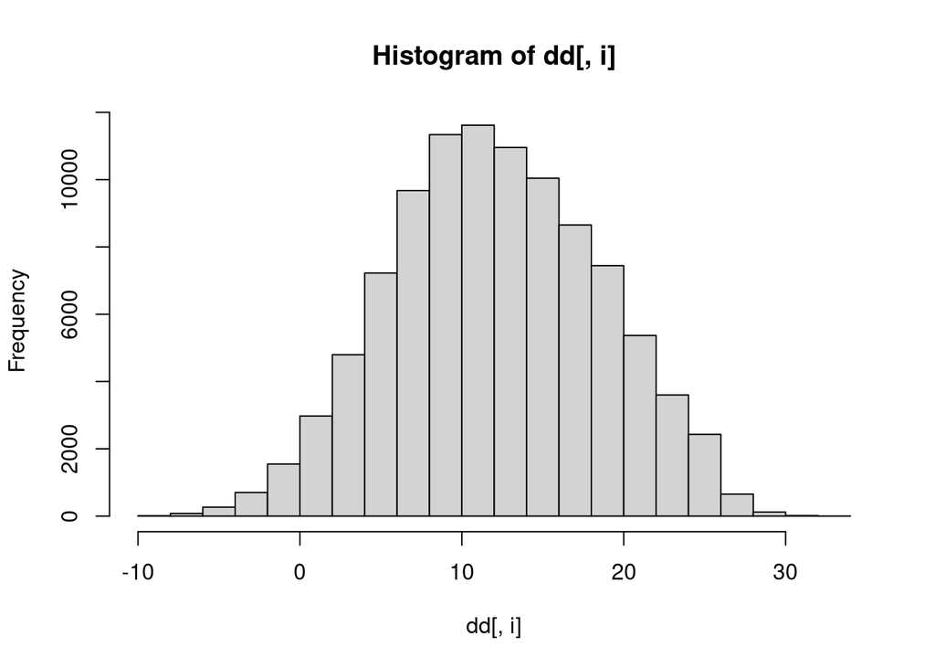

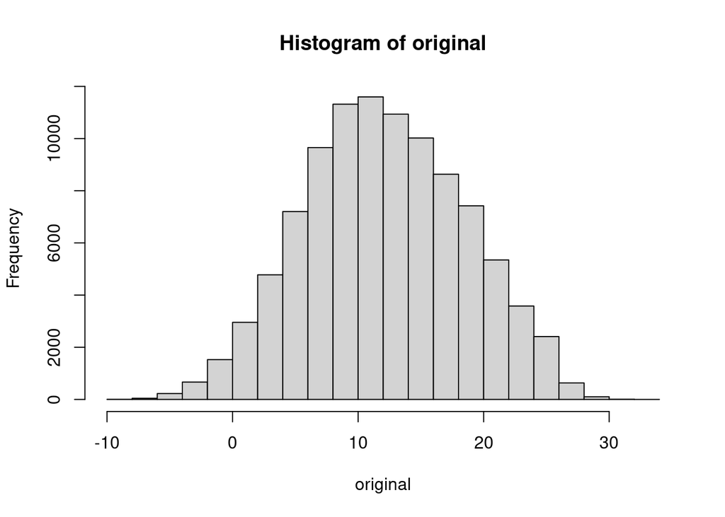

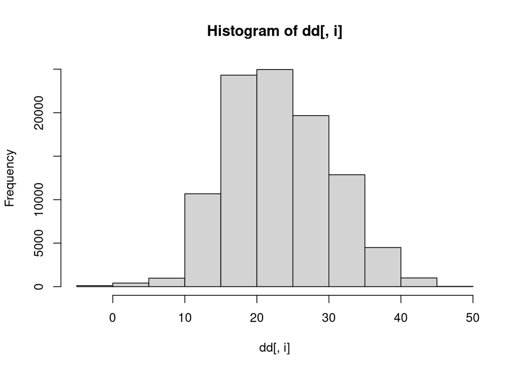

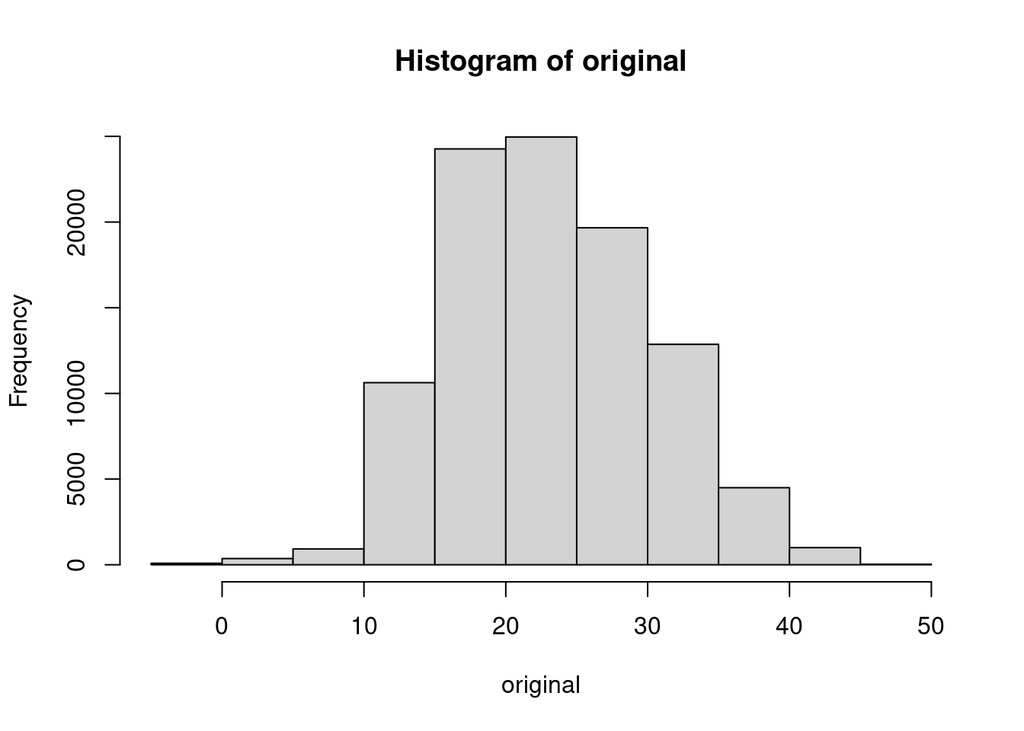

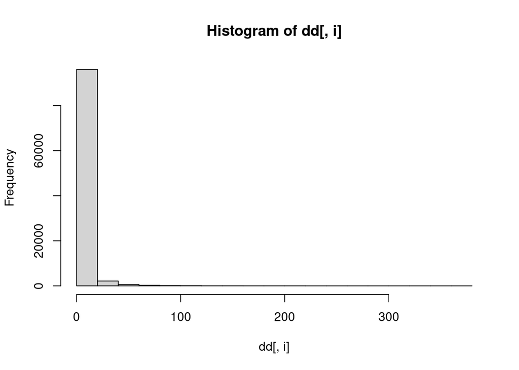

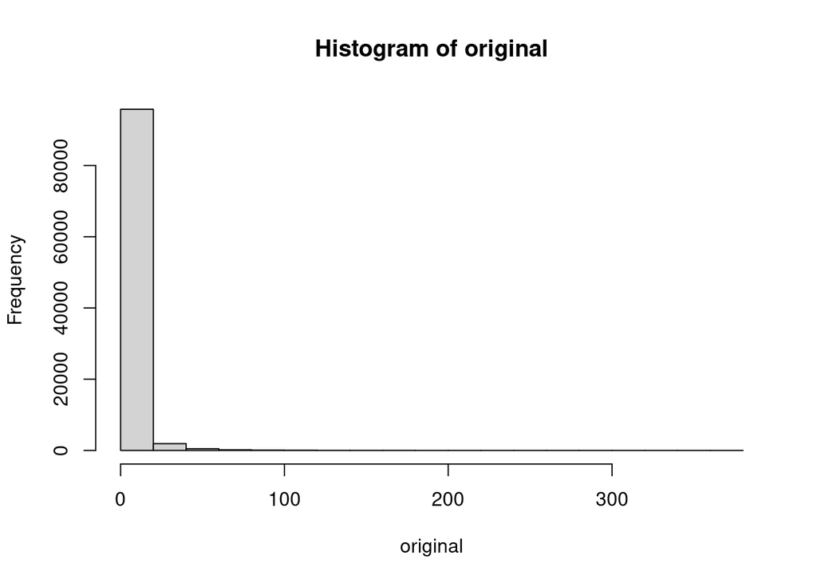

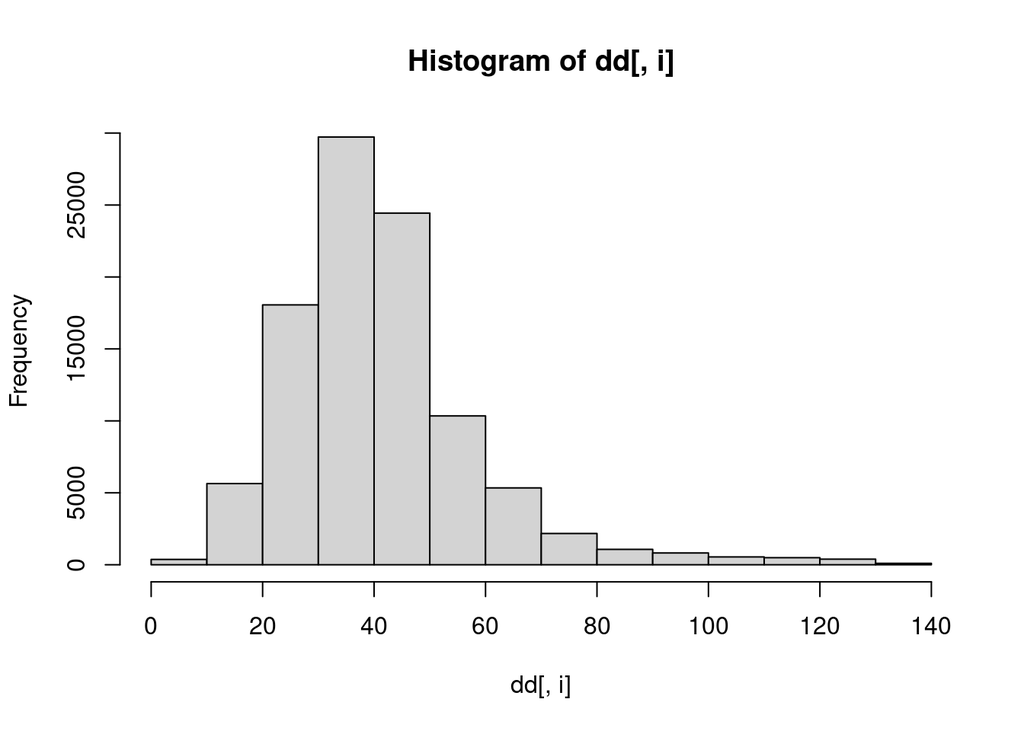

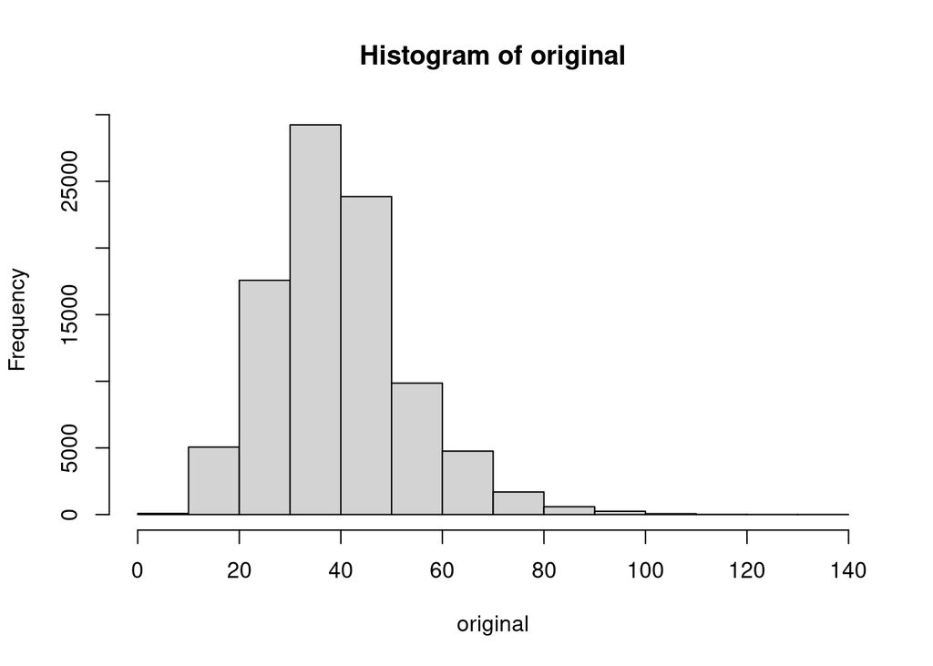

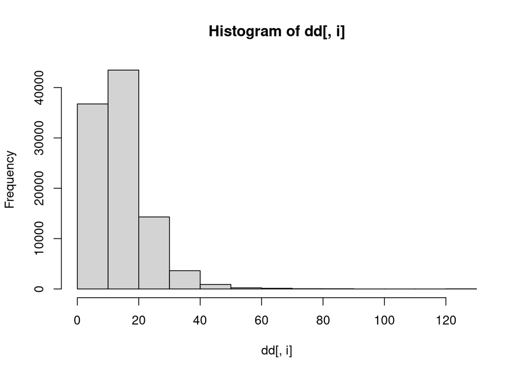

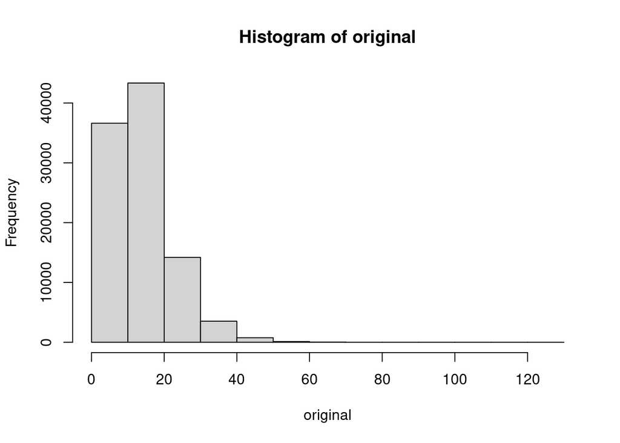

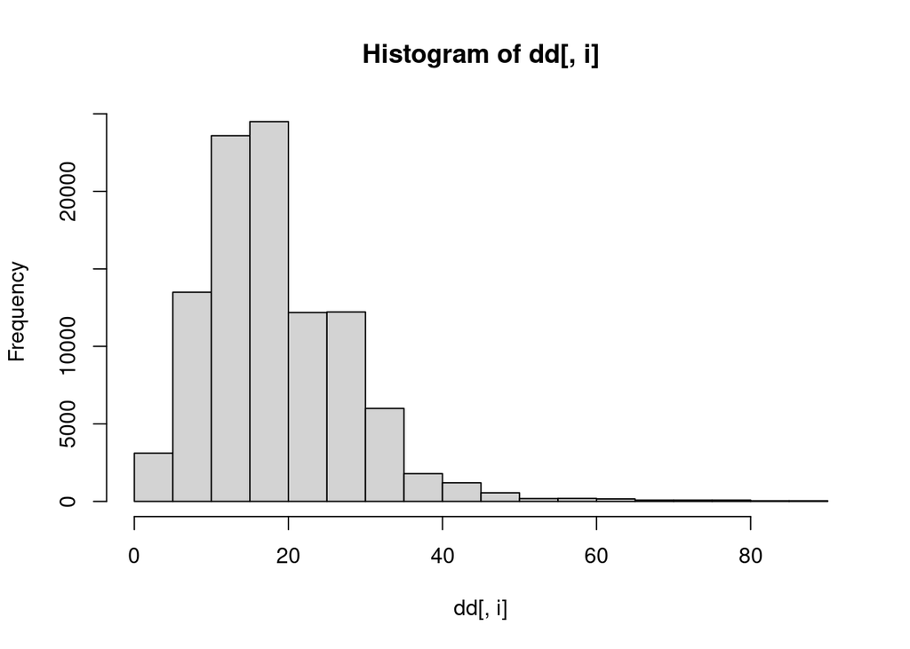

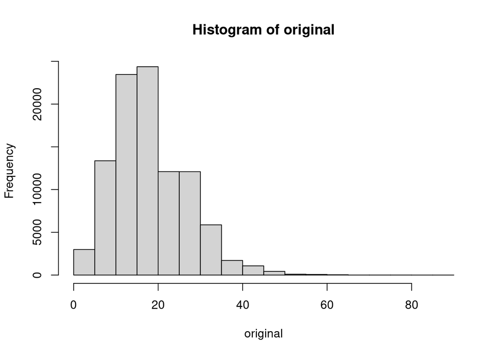

[12 more figures not shown]

```r
numVariables<-c(3, 4, 5, 7, 10, 11, 12, 13, 14, 15, 16, 17)

library(class)

# FOR EVERY INDIVIDUAL WITH MISSING Incomes LOOK FOR THE MOST SIMILAR INDIVIDUAL
# wrt REMAINING VARIABLES AND COPY THE VALUE OF INGRESSOS ON THE FIRST
#For more robustness average the values of k-NN in general (with small k)


# For a single variable:
# Build an artificial matrix with the full numerical variables

mediana <- aux
for(c in 1:ncol(aux)) {
  mediana[is.na(aux[,c]),c] <- mean(mediana[,c], na.rm = TRUE)
}

fullVariables<-c(3, 4, 5, 7, 10, 11, 12, 13, 14, 15, 16, 17)
for (i in fullVariables) {
  aux<-dd[,fullVariables]
  dim(aux)
  names(aux)

  aux1 <- mediana[!is.na(dd[,i]),]
  dim(aux1)
  aux2 <- mediana[is.na(dd[,i]),]
  dim(aux2)

  knn.ing = knn(aux1,aux2,dd[,i][!is.na(dd[,i])])

  original<-dd[,i]
  dd[,i][is.na(dd[,i])] <- as.numeric(levels(knn.ing))

  hist(dd[,i])
  summary(dd[,i])
  hist(original)
  summary(original)
}
```

```r
colnames(dd)<-c("Row", "Loc", "MinT", "MaxT", "Rain", "WDir", "WSpeed", "WDir9", "WDir3", "WSpeed9", "WSpeed3", "Hum9", "Hum3", "Press9", "Press3", "Temp9", "Temp3", "Rtod", "RTom")

for (i in indexColumnas) {
  columnTitle <- names(dd)[i]
  columnaValores <- dd[,i]
  print(columnTitle)
  print(sum(is.na(columnaValores)))
}
```

```
## [1] "Loc"
## [1] 0
## [1] "MinT"
## [1] 0
## [1] "MaxT"
## [1] 0
## [1] "Rain"
## [1] 0
## [1] "WDir"
## [1] 6521
## [1] "WSpeed"
## [1] 0
## [1] "WDir9"
## [1] 7006
## [1] "WDir3"
```

[output cut: 21 more lines]

```r
write.table(dd, sep = ",","sinMissings.csv")
```